# Short comp sans shiny

Bastien Grasset

09/02/2022

The purpose of this markdown is to describe the differences of data from the World Tuna Atlas following the different filters. It describes the differences between the initial data and the final data, and is intended for users of the final data who might be tempted to use it without taking into account the various filtering specificities.

*Attention ! All the differences inferior to 0 corresponds to gain in captures.*

# 1 The data compared

The analyzed data are :

- *acces treatment_after_binding for the initial data*
- *acces mapping_codelist for the final data*

# 2 Main differences

The number of lines goes from 4.703429 millions in treatment_after_binding to 4.55159 millions in mapping_codelist, which correspond to a difference of 3.22826%.

The initial dataset has a total of 103386195 in tons and of 1148126339 in number of fish.

The final dataset has a total of 103386195 in tons and of 1148126339 in number of fish.

The differences is 0 in tons (**0%**). The differences is 0 in number of fish (**0**).

The stratas differences between the first one and the second one represents 1 % of the total number of stratas.

# 3 Introduction to the two datasets

## 3.1 Spatial coverage

# 4 Differences

This section detail the different differences that observed between the dataframe treatment_after_binding and mapping_codelist.

## 4.1 The differences for each dimension

We will look for each dimension the 6 most important differences

| Dimension | unit | Loss / Gain | Precision | Captures table 1 | Difference (in %) | Difference in millions of tons/fish |
| --- | --- | --- | --- | --- | --- | --- |
| Name_En |  |  |  |  |  |  |
|  | Number of fish |  |  |  |  |  |
|  |  | Gain |  |  |  |  |
|  |  |  | Gear not known | 0 | -Inf | -0.03 |
|  |  |  | Gear nei | 0 | -Inf | -1.38 |
|  |  |  | Drift gillnets | 0 | -Inf | -8.83 |
|  |  |  | Gillnets and entangling nets (nei) | 0 | -Inf | -11.09 |
|  |  |  | Drifting longlines | 0 | -Inf | -239.81 |
|  |  |  | Others | 0 | -Inf | -886.99 |
|  |  | Loss |  |  |  |  |
|  |  |  | NA | 1,148,126,339 | 100.00 | 1,148.13 |
|  | Tons |  |  |  |  |  |
|  |  | Gain |  |  |  |  |
|  |  |  | Aerial traps | 0 | -Inf | 0.00 |
|  |  |  | Cast nets | 0 | -Inf | 0.00 |
|  |  |  | Beach seines | 0 | -Inf | -0.09 |
|  |  |  | Drift gillnets | 0 | -Inf | -0.49 |
|  |  |  | Drifting longlines | 0 | -Inf | -4.23 |
|  |  |  | Others | 0 | -Inf | -98.58 |
|  |  | Loss |  |  |  |  |
|  |  |  | NA | 103,386,195 | 100.00 | 103.39 |
| species |  |  |  |  |  |  |
|  | Number of fish |  |  |  |  |  |
|  |  | Gain |  |  |  |  |
|  |  |  | SPN | 6,310 | -162.44 | -0.01 |
|  |  |  | UNK | 0 | -Inf | -120.06 |
|  |  | Loss |  |  |  |  |
|  |  |  | OTH | 76,265,787 | 100.00 | 76.27 |
|  |  |  | NTAD | 29,698,548 | 100.00 | 29.70 |
|  |  |  | Others | 16,243,630 | 78.13 | 12.69 |
|  |  |  | BILL | 1,321,158 | 100.00 | 1.32 |
|  |  |  | oSks | 85,176 | 100.00 | 0.09 |
|  |  |  | HAM | 10,250 | 100.00 | 0.01 |
|  | Tons |  |  |  |  |  |
|  |  | Gain |  |  |  |  |
|  |  |  | UNK | 0 | -Inf | -4.09 |
|  |  | Loss |  |  |  |  |
|  |  |  | OTH | 1,764,760 | 100.00 | 1.76 |
|  |  |  | NTAD | 1,607,906 | 100.00 | 1.61 |
|  |  |  | oTun | 370,458 | 100.00 | 0.37 |
|  |  |  | BILL | 258,396 | 100.00 | 0.26 |
|  |  |  | oSks | 88,785 | 100.00 | 0.09 |

## 4.2 Differences in geographical data

Here is represented for each area the polygons keeping all the initial information, the one losing a part and the one losing all the information.

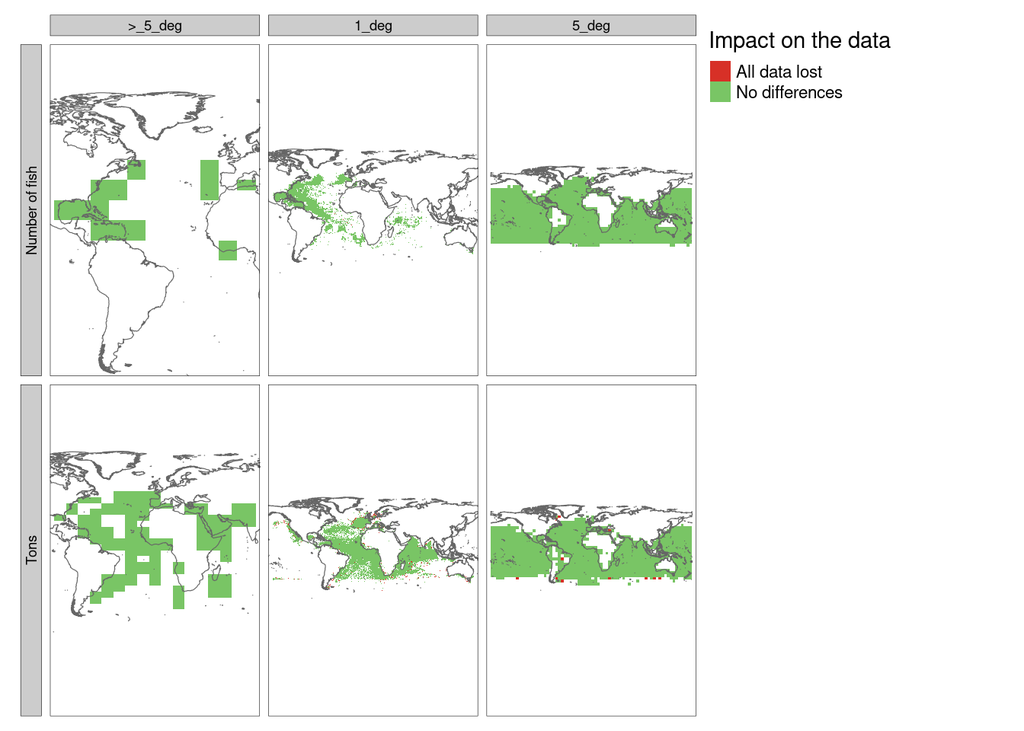

## 4.3 Differences in temporal data

[figure not shown]